# First_Quarto_File

Author

Sayal Neupane

# Article Reviews

## 1. [How Music Taste Evolved – The Pudding](https://pudding.cool/2017/03/music-history/)

**What’s good:** This article uses interactive line plots to let readers explore decades of Billboard chart data. Visuals are animated and layered, showing genre rise and fall. The experience is very engaging.

**What could be better:** The interactivity is so heavy that on slower computers or mobile, it can lag or become hard to follow.

## 2. [CO₂ and Greenhouse Gas Emissions – Our World in Data](https://ourworldindata.org/co2-and-other-greenhouse-gas-emissions)

**What’s good:** The article uses interactive global maps and line charts. You can filter data by country and timeframe, making it a great exploration tool.

**What could be better:** The large number of filters and options can be overwhelming for first-time users unfamiliar with data analysis.

## 3. [33 Cool Charts We Made In 2022 – FiveThirtyEight](https://fivethirtyeight.com/features/best-charts-2022/)

**What’s good:** This article shows a fun collection of charts from different topics like politics, sports, and science. Each chart tells a quick, clear story and uses smart color and layout choices to make the message easy to see.

**What could be better:** Some charts don’t give enough background or source details. A little more explanation would help readers understand the full story behind the data.

Here’s an R chunk for a simple plot:

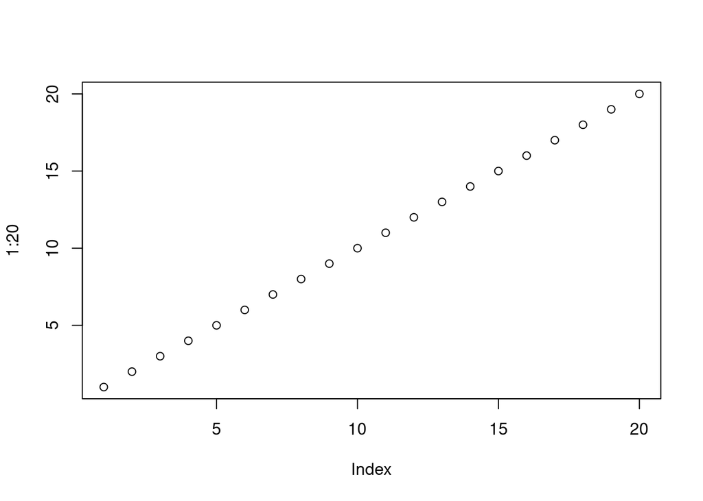

```r
plot(1:20)
```